# Chapter1. Python语言基础

# Chapter1. Python语言基础

## 1.1 语言基础

### 1.1.1 标量类型

Python的标准库中拥有一个小的内建类型集合，用来处理数值数据、字符串、布尔值、日期和时间，这类“单值”类型称为标量类型。标准Python标量类型包括：

- None：null值
- str：字符串
- bytes：原生ASCII字节
- float：双精度64位浮点数
- bool：布尔值，True或False
- int：整数
- datetime\date\time：使用标准库中的datetime模块

#### ① 数值

整数 int 和浮点数 float

```python
a = 78  #int 整数
b = 3
c = 7.8  #float 浮点数
a/c
```

```
10.0
```

```python
a/b  #整数除法会把结果自动转型为浮点数
```

```
26.0
```

```python
3//2  #整除操作符
```

```
1
```

#### ② 字符串

```python
a = 'today'  #单引号
b = "Monday"  #双引号
#多行字符串可使用三个引号
c = '''
today is Monday
it's sunny
'''
print(c)
```

```
today is Monday
it's sunny
```

```python
# 两个字符串通过+产生一个新字符串
print(a+' is '+b)
```

```
today is Monday
```

```python
# len()返回字符串的长度
len(c)
```

```
28
```

```python
d = 7.9
s = str(d)  #Python对象可以通过str函数转成字符串
print(s)
```

```
7.9
```

```python
# 字符串可以被看作是除了列表和元组外的另一种序列
s = 'Python'
s[:3]  #切片
```

```
'Pyt'
```

```python
s = 'This book is Tom\'s'  #反斜杠符号\是一种转义符号
print(s)
```

```
This book is Tom's
```

User input：允许用户输入，属于字符串

```python
name = input('What\'s your name?')
print('Hello, '+name+'!')
```

```
What's your name?Qian
Hello, Qian!
```

```python
# 将输入转化为数值型
age = input('How old are you?')
age5 = int(age)+5
print('5 years later: ',age5)
```

```
How old are you?18
5 years later:  23
```

```python
print('{0}的年龄是{1},5年后年龄是{2}'.format(name,age,age5))
```

```
Qian的年龄是18,5年后年龄是23
```

#### ③ 布尔值

```python
#比较运算和条件表达式的结果用布尔值True或False来表示
1==2
```

```
False
```

```python
# 可以与and和or关键词合用
print(True and False)
print(True or False)
```

```
False
True
```

#### ④ null值

```python
# 如果一个函数没有显式的返回值，则会隐式地返回None
a = None
print(a)
```

```
None
```

```python
a is None
# a == None
```

```
True
```

#### ⑤ 日期和时间

```python
from datetime import datetime,date,time
dt = datetime(2020,9,1,6,10,30)
print(dt.day)
print(dt.minute)
```

```
1
10
```

```python
# 分别使用date和time方法获取date和time对象
import datetime
dt = datetime.datetime.now()
print(dt.date())
print(dt.time())
```

```
2023-09-13
16:28:32.139859
```

```python
#strftime方法将datetime转换为字符串
print(dt.strftime('%m/%d/%Y %H:%M'))
print(dt.strftime('%F')) # %F为 %Y-%m-%d的简写
```

```
09/13/2023 16:28
2023-09-13
```

### 1.1.2 控制流

标准控制流在Python中通过一些条件逻辑、循环等内建关键字的方式实现。

#### ① if 语句

if条件语句式最广为人知的控制流类型。一个if语句可以接多个elif代码块和一个else代码块。如果某个条件为True，则后面的elif和else代码块不会执行；如果所有elif条件均为False，则执行else代码块。

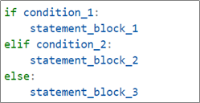

Python中的三元表达式允许将一个if-else代码块联合起来，在一行代码或一个语句中生成数据。使用三元表达式可以压缩代码量，但同时也会牺牲可读性。

```python
x = 10
if x<0:
    print('It\'s negative')
else:
    print('It\'s positive!')
```

```
It's positive!
```

```python
x = int(input())
if x<0:
    print('It\'s negative')
elif x==0:
    print('Equal to zero')
elif x<10:
    print('Positive but smaller than 10')
else:
    print('Positive but larger than or equal to 10')
```

```
8
Positive but smaller than 10
```

```python
# 三元表达式
print('It\'s negative!') if x<0 else print('It\'s positive!')
```

```
It's positive!
```

#### ② while循环

会在条件判断为True的情况下一直执行代码块，直到条件判断为False时结束。

```python
a = 1
while a < 10:
    if a%2==0:
        print(a,'is even')
    else:
        print(a,'is odd')
    a += 1
```

```
1 is odd
2 is even
3 is odd
4 is even
5 is odd
6 is even
7 is odd
8 is even
9 is odd
```

#### ③ for循环

用于遍历一个集合（比如列表、元组等）或一个迭代器（比如range函数返回的序列），遍历的顺序与元素在序列中出现的顺序一致。

```python
# 内置函数range()可以生成整数序列
for a in range(1,10):
    if a%2==0:
        print(a,'is even')
    else:
        print(a,'is odd')
```

```
1 is odd
2 is even
3 is odd
4 is even
5 is odd
6 is even
7 is odd
8 is even
9 is odd
```

```python
for i in range(0,10,2):
    print(i,end=' ')
```

```
0 2 4 6 8
```

```python
words = ['tea','coffee','Coca Cola']
for w in words:
    print(w,len(w))
```

```
tea 3
coffee 6
Coca Cola 9
```

#### ④ 循环中的关键字

break关键字可以结束当前循环（如果多循环嵌套，则结束内层循环）；

continue关键字可以跳过continue之后的代码进入下一次循环；

else子句会在遍历完序列（for循环）或条件判断为False（while循环）时被执行，但不会在break终止时执行。

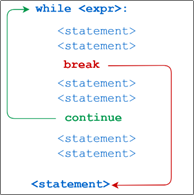

```python
while True:
    input_str = input("Enter an integer, type quit if wannna stop ")
    if input_str == 'quit':
        break
    number = int(input_str)
    if number < 0:
        continue

    if number % 2 == 0:
        print(number,"is even")
    else:
        print(number,"is odd")
```

```
Enter an integer, type quit if wannna stop 9
9 is odd
Enter an integer, type quit if wannna stop 10
10 is even
Enter an integer, type quit if wannna stop -8
Enter an integer, type quit if wannna stop quit
```

```python
# 以上代码也可以不使用continue，但对比发现嵌套层次更深，降低运行性能，不利于理解
while True:
    input_str = input("Enter an integer, type quit if wannna stop ")
    if input_str == 'quit':
        break
    number = int(input_str)
    if number >= 0:
        if number % 2 == 0:
            print(number,"is even")
        else:
            print(number,"is odd")
```

```
Enter an integer, type quit if wannna stop 9
9 is odd
Enter an integer, type quit if wannna stop 10
10 is even
Enter an integer, type quit if wannna stop -8
Enter an integer, type quit if wannna stop quit
```

#### ⑤ pass语句

就是Python中的“什么都不做语句”。当语法上需要一个语句（因为Python使用了缩进来分隔代码块），但实际上不需要执行任何操作时，可以使用pass语句。或者可以作为还没有实现的代码占位符。

```python
# pass
x=8
if x<0:
    print('It\'s negative!')
elif x==0:
    pass
else:
    print('It\'s positive!')
```

```
It's positive!
```

## 1.2 数据结构和序列

Python的常用数据结构包括：元组、列表、字典和集合。

### 1.2.1 元组Tuple

固定长度、不可变的Python对象序列

#### ① 创建和获取元组

```python
# 创建元组：用逗号分隔序列值
tup = 4,5,6
tup
```

```
(4, 5, 6)
```

```python
# 嵌套元组：定义复杂的元组时，可以用括号()将值包起来
tup0 = (4,5,6),(7,8)
tup0
```

```
((4, 5, 6), (7, 8))
```

```python
# 元组的元素可以通过中括号来获取，一旦创建无法被修改
tup0[0]
```

```
(4, 5, 6)
```

```python
# 使用tuple函数将任意序列或迭代器转换为元组
tup1 = tuple('string')
tup1[1]
```

```
't'
```

```python
# 使用+号连接元组来生成更长的元组
tup2 = tup+(7,8)
tup2
```

```
(4, 5, 6, 7, 8)
```

```python
# 将元组乘以整数，会和列表一样生成含有多份拷贝的元组
tup*2
```

```
(4, 5, 6, 4, 5, 6)
```

#### ② 元组拆包

```python
# 元组拆包：将元组的值进行拆包，赋值给变量
a,b,c = tup
b
```

```
5
```

```python
# 拆包的一个常用场景就是遍历元组或列表组成的序列
seq = [(1,2,3),(4,5,6)]
for a,b,c in seq:
    # print(a,b,c)
    print('a={0},b={1},c={2}'.format(a,b,c))
```

```
a=1,b=2,c=3
a=4,b=5,c=6
```

#### ③ 元组方法

```python
# 元组的方法：方法不多，常用的count用于计量某个数值在元组中出现的次数
tup.count(4)
```

```
1
```

### 1.2.2 列表List

长度可变、内容可修改的Python对象序列

#### ① 创建和获取列表

```python
# 使用中括号[]或list类型函数来定义列表
a_list = [2,3,5,7,None]
a_list
```

```
[2, 3, 5, 7, None]
```

```python
# list函数常用于将迭代器或生成器转化为列表
gen = range(10)
list(gen)
```

```
[0, 1, 2, 3, 4, 5, 6, 7, 8, 9]
```

```python
# 列表内容可修改
a_list[0] = 1
a_list
```

```
[1, 3, 5, 7, None]
```

```python
# 使用in或notin 关键字可以检查一个值是否在列表中
None in a_list
```

```
True
```

```python
None not in a_list
```

```
False
```

#### ② 增加和移除元素

```python
# append方法将元素添加到列表尾部
a_list.append('string')
a_list
```

```
[1, 3, 5, 7, None, 'string']
```

```python
# insert方法将元素插入到指定位置
a_list.insert(1,'abc')
a_list
```

```
[1, 'abc', 3, 5, 7, None, 'string']
```

```python
# pop是insert的反操作将特定位置的元素移除并返回
a_list.pop(1)
a_list
```

```
[1, 3, 5, 7, None, 'string']
```

```python
# remove方法会定位第一个符合要求的值并移除
a_list.append(None)
a_list.remove(None)
a_list
```

```
[1, 3, 5, 7, 'string', None]
```

#### ③ 连接和联合列表

```python
# 两个列表可以使用+号连接
a_list+list(range(10,20,2))
```

```
[1, 3, 5, 7, 'string', None, 10, 12, 14, 16, 18]
```

```python
# 或者使用extend方法向该列表添加多个元素
a_list.extend([10,12,(1,2)])
a_list
```

```
[1, 3, 5, 7, 'string', None, 10, 12, (1, 2)]
```

#### ④ 切片

可以对大多数序列类型选取子集，基本形式是[start:stop]，start的索引是包含的，而stop索引不包含，切片的数量是stop-start

```python
seq = list(range(0,20,2))
seq
```

```
[0, 2, 4, 6, 8, 10, 12, 14, 16, 18]
```

```python
seq[1:5] #从1号位开始，数量为4
```

```
[2, 4, 6, 8]
```

```python
seq[3:4] = [6,7]
seq
```

```
[0, 2, 4, 6, 7, 8, 10, 12, 14, 16, 18]
```

```python
seq[:5] #start省略，返回前5个元素
```

```
[0, 2, 4, 6, 7]
```

```python
seq[3:] #stop省略，表示从3号位开始到结束位置
```

```
[6, 7, 8, 10, 12, 14, 16, 18]
```

```python
seq[-4:] #负索引从序列的尾部进行索引，表示最后4个元素
```

```
[12, 14, 16, 18]
```

```python
seq[-6:-2]
```

```
[8, 10, 12, 14]
```

```python
# 步进值step可以在第二个冒号后面使用，意思是每隔多少个元素取一个值
seq[::2]
```

```
[0, 4, 7, 10, 14, 18]
```

```python
# 当需要对序列进行翻转时，一个聪明的方法就是将步进值设置为-1
seq[::-1]
```

```
[18, 16, 14, 12, 10, 8, 7, 6, 4, 2, 0]
```

### 1.2.3 字典Dict

无序的键key：值value对的集合（键不可变：标量类型或元组）

#### ① 创建和获取字典

```python
#用大括号{}创建字典，在字典中用逗号将键值对分隔
d1={'a':'value','b':[1,2,3]}
d1
```

```
{'a': 'value', 'b': [1, 2, 3]}
```

```python
# 访问字典中的元素，与列表和元组类似
d1['b']
```

```
[1, 2, 3]
```

```python
# 插入字典中的元素
d1[5] = 5
d1[7] = 7
d1
```

```
{'a': 'value', 'b': [1, 2, 3], 5: 5, 7: 7}
```

```python
# 设置字典中的元素
d1[5] = 'integer'
d1
```

```
{'a': 'value', 'b': [1, 2, 3], 5: 'integer', 7: 7}
```

```python
# 使用del关键字删除值
del d1[5]
d1
```

```
{'a': 'value', 'b': [1, 2, 3], 7: 7}
```

```python
# 使用pop方法删除值
d1.pop(7)
d1
```

```
{'a': 'value', 'b': [1, 2, 3]}
```

#### ② 字典的方法

```python
# keys方法和values方法会分别提供字典的键、值迭代器
d1.keys()
```

```
dict_keys(['a', 'b'])
```

```python
d1.values()
```

```
dict_values(['value', [1, 2, 3]])
```

```python
# items方法：当在字典中循环时，用items()方法可将键和值同时取出
for i,v in d1.items():
    print('{0} : {1}'.format(i,v))
```

```
a : value
b : [1, 2, 3]
```

```python
# update方法可以将两个字典合并，相同键值则会被覆盖
d1.update({'c':9,'b':(1,2,3)})
d1
```

```
{'a': 'value', 'b': (1, 2, 3), 'c': 9}
```

### 1.2.4 集合Set

无序且元素唯一的容器，与字典类似，但只有键没有值

#### ① 创建集合

```python
# 通过set()函数创建集合
s1 = set([2,2,2,1,3,3])
s1
```

```
{1, 2, 3}
```

```python
# 通过大括号{}创建集合
s2 = {2,2,2,1,3,3}
s2
```

```
{1, 2, 3}
```

```python
# 集合元素不可变
seq = list(range(10))
seq
```

```
[0, 1, 2, 3, 4, 5, 6, 7, 8, 9]
```

```python
s3 = {seq}
```

```
---------------------------------------------------------------------------
TypeError                                 Traceback (most recent call last)
/var/folders/tf/qlv2bsg56cdds2_0cs3hvf580000gn/T/ipykernel_71496/2934282750.py in <module>
----> 1 s3 = {seq}

TypeError: unhashable type: 'list'
```

```python
# 如果想要包含列表型的元素，必须先转换为元组
s3 = {tuple(seq)}
s3
```

```
{(0, 1, 2, 3, 4, 5, 6, 7, 8, 9)}
```

#### ② 集合操作

```python
a = {1,2,1,2,3,4}
b = {3,4,3,4,5,6}
print(a)
print(b)
```

```
{1, 2, 3, 4}
{3, 4, 5, 6}
```

```python
# 集合的并集
print(a | b)
print(a.union(b))
```

```
{1, 2, 3, 4, 5, 6}
{1, 2, 3, 4, 5, 6}
```

```python
# 集合的交集
print(a & b)
print(a.intersection(b))
```

```
{3, 4}
{3, 4}
```

### 1.2.5 内建序列函数

#### ① `range()`函数

当需要遍历一个整数序列时，`range()`函数会派上用场。

```python
# 生成一个可迭代的整数序列
# 是一个生成器，需要list或for循环进行实例化
range(10)
```

```
range(0, 10)
```

```python
# 用for循环遍历
for i in range(10):
    print(i,end=' ')
```

```
0 1 2 3 4 5 6 7 8 9
```

```python
# start,stop,step 默认为1
for i in range(1,10,2):
    print(i,end=' ')
```

```
1 3 5 7 9
```

#### ② `enumerate()`函数

当在序列中循环时，用`enumerate()`函数可以同时获取索引位置和其对应的值。

```python
a_list = ['bb','cc','aa']
for i,v in enumerate(a_list):
    print(i,v)
```

```
0 bb
1 cc
2 aa
```

```python
# 构造一个字典,使用enumerate函数将序列值映射到索引位置上
mapping = {}
for i,v in enumerate(a_list):
    mapping[v]=i
mapping
```

```
{'bb': 0, 'cc': 1, 'aa': 2}
```

#### ③ `zip()`函数

当同时在两个或以上序列中循环时，可以用`zip()`函数将其内的元素以元组的形式一一配对。

```python
a_list = ['a','b','c','d']
b_list = [1,3,5,7]
```

```python
# 用for循环同时遍历两个列表
for a,b in zip(a_list,b_list):
    print('{0} = {1}'.format(a,b))
```

```
a = 1
b = 3
c = 5
d = 7
```

```python
# 与enumerate()函数同时使用
for i,(a,b) in enumerate(zip(a_list,b_list)):
    print('Index{0}:{1}={2}'.format(i,a,b))
```

```
Index0:a=1
Index1:b=3
Index2:c=5
Index3:d=7
```

```python
# 新构成的序列长度由最短的序列决定
c_list = [True,False]
list(zip(a_list,b_list,c_list))
```

```
[('a', 1, True), ('b', 3, False)]
```

#### ④ `sorted()`函数

可以在不改动原序列的基础上返回一个按照指定顺序排序的序列。

```python
a_list=[7,1,2,6,0,3,2]
sorted(a_list)
```

```
[0, 1, 2, 2, 3, 6, 7]
```

返回一个倒序排列表。

```python
# 逆向循环一个整数序列
for i in reversed(range(10)):
    print(i,end=' ')
```

```
9 8 7 6 5 4 3 2 1 0
```

### 1.2.6 推导式

推导式是很受欢迎的Python语言特性之一，允许过滤一些元素，以一种简明的表达方式生成一个新的序列。

#### ① 列表推导式

`[expr for val in collection if condition]`

```python
a_list = ['beer','wine','rum','coffee','tea','Coca Cola']
[v.upper() for v in a_list if len(v)>3]
```

```
['BEER', 'WINE', 'COFFEE', 'COCA COLA']
```

#### ② 集合推导式

`{expr for val in collection if condition}`

```python
{len(v) for v in a_list}
```

```
{3, 4, 6, 9}
```

#### ③ 字典推导式

`{key-expr:val-expr for val in collection if condition}`

```python
{v:i for i,v in enumerate(a_list) if len(v)>3}
```

```
{'beer': 0, 'wine': 1, 'coffee': 3, 'Coca Cola': 5}
```

### 1.2.7 生成器 Generator

如果列表元素可以按照某种算法推算出来，那我们是否可以在循环的过程中不断推算出后续的元素呢？这样就不必创建完整的列表，从而节省大量的空间。在Python中，这种一边循环一边计算的机制，称为生成器Generator。生成器被用作控制循环的迭代行为，是迭代器的一种。

#### ① 生成器表达式

使用生成器表达式来创建生成器，与列表推导式很类似，只需将中括号替换为小括号。

```python
# 使用推导式创建一个列表
a_list = [i**2 for i in range(10)]
a_list
```

```
[0, 1, 4, 9, 16, 25, 36, 49, 64, 81]
```

```python
# 使用生成器表达式创建一个列表生成器
b_list = (i**2 for i in range(10))
b_list
```

```
<generator object <genexpr> at 0x7fd4f02cba50>
```

#### ② 生成器实例化

之前学习的内建序列函数很多也属于生成器，一般可以通过`list()`函数或for循环来进行实例化。

```python
# 使用for循环来进行遍历
for i in b_list:
    print(i,end=' ')
```

```
0 1 4 9 16 25 36 49 64 81
```

```python
range(10)
```

```
range(0, 10)
```

```python
reversed(range(10))
```

```
<range_iterator at 0x7fd4e004a990>
```

```python
# 使用list()函数将其实例化
list(reversed(range(10)))
```

```
[9, 8, 7, 6, 5, 4, 3, 2, 1, 0]
```

## 1.3 函数、模块和包

### 1.3.1 函数Function

函数是Python中最重要、最基础的代码组织和代码复用方式。如果需要多次重复相同或类似的代码，就非常值得写一个可复用的函数。

函数声明时使用def关键字，后面跟函数名称和带括号的形参，返回时使用return关键字（允许多条return语句，如果达到函数尾部仍然没有遇到return语句则会自动返回None）。

#### ① 定义和调用函数

```python
# 函数声明时使用def关键字，后面跟函数名称和带括号的形参，返回时使用return关键字。
def fct(x,y,z=1):
    if z>=1:
        return z*(x+y)
    else:
        return x+1,y+2
```

```python
# x,y是位置参数，z是关键字参数，用于指定默认值或可选参数，可以没有，有的话需在最后
fct(5,6)
```

```
11
```

```python
# 调用fct函数
fct(5,6,7)
```

```
77
```

```python
# 也可使用形参=实参的形式，有助于代码可读性
fct(x=5,y=6,z=7)
```

```
77
```

```python
# 返回多个值:即返回多个值组成的元组
fct(x=5,y=6,z=0.7)
```

```
(6, 8)
```

```python
# 元组可进一步做拆包
a,b=fct(x=5,y=6,z=0.7)
b
```

```
8
```

#### ② 匿名Lambda函数

匿名函数（Lambda）是一种通过单个语句生成函数的方式。

之所以被称为匿名函数，是因为允许没有一个显示的函数名称。定义匿名函数只需使用lambda关键字，后面跟形参：返回值。匿名函数在数据分析中经常会使用到，将它作为参数进行传值，代码量小，比写一个完整的函数更为方便。

```python
# 定义Lambda函数只需使用lambda关键字，后面跟形参：返回值。
fct2 = lambda x:x**2
```

```python
# 调用Lambda函数
fct2(5)
```

```
25
```

```python
# Lambda函数在数据分析中经常作为参数进行传值
seq = ['beer','wine','rum','coffee','tea','Coca Cola']

# 根据字符串的长度对列表进行排序
sorted(seq,key=lambda x:len(x))
```

```
['rum', 'tea', 'beer', 'wine', 'coffee', 'Coca Cola']
```

```python
# 根据字符串的字母顺序（忽略大小写）进行排序
sorted(seq,key=lambda x:x.lower())
```

```
['beer', 'Coca Cola', 'coffee', 'rum', 'tea', 'wine']
```

#### Practice

```python
# 定义一个打印斐波那契数列的函数
def fib(n):
    a,b=0,1
    while a<n:
        print(a,end=' ')
        a,b = b,a+b
    print()
```

```python
fib(100)
```

```
0 1 1 2 3 5 8 13 21 34 55 89
```

```python
# 定义一个返回斐波那契数列的列表的函数
def fib2(n):
    result=[]
    a,b=0,1
    while a<n:
        result.append(a)  # 列表的append方法，在列表最后添加元素
        a,b=b,a+b
    return result
```

```python
fib2(200)
```

```
[0, 1, 1, 2, 3, 5, 8, 13, 21, 34, 55, 89, 144]
```

### 1.3.2 模块 Module

模块就是包含Python定义和语句的，以.py作为后缀名的文件。

当你退出Python解释器后，之前的定义（类、函数、变量等）都会消失。或者当你想在不同的程序中使用一个函数，需要将函数复制到每一个程序中。Python提供了一种方法，将这些定义存储在被一个称为模块的独立文件中，再使用import语句将模块导入到主程序中，允许当前程序中使用模块中的代码。

在当前目录下创建一个名为fibo.py的文件，含有以下代码。然后进入Python解释器，导入该模块并调用其中的函数。

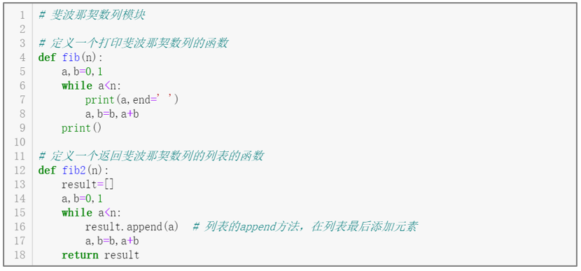

#### ① import语句

```python
# 导入fibo模块
import fibo
```

```python
# 并未导入模块中的函数，需要使用模块名fibo访问函数fib
fibo.fib(100)
```

```
0 1 1 2 3 5 8 13 21 34 55 89
```

```python
# 用模块名fibo访问函数fib2
fibo.fib2(200)
```

```
[0, 1, 1, 2, 3, 5, 8, 13, 21, 34, 55, 89, 144]
```

```python
# 如果经常使用某个函数，可以将其赋值给一个局部变量
f=fibo.fib
f(100)
```

```
0 1 1 2 3 5 8 13 21 34 55 89
```

#### ② from...import 语句

```python
# 从模块中导入一部分指定的对象
from fibo import fib
```

```python
# 直接访问函数fib
fib(100)
```

```
0 1 1 2 3 5 8 13 21 34 55 89
```

```python
# import语句的变体，导入模块内定义的所有对象，慎用
from fibo import *
```

```python
# 直接访问函数fib2
fib2(200)
```

```
[0, 1, 1, 2, 3, 5, 8, 13, 21, 34, 55, 89, 144]
```

### 1.3.3 包 Package

包可以看作是一个允许不断增长的模块的集合。

包通过“带点号的模块名”来对包中的模块名命，比如模块名A.B表示A包中的名为B的子模块。这样一来，来自不同包之间的模块就不会出现重名的情况。包的导入与模块的导入方式大致相同。

1. 导入包package：
- `import package [as nickname]` 使用全称/别称去访问item
1. 导入包中特定的模块module：
- `import package[.subpackage].module` 使用全称去访问item
- `from package[.subpackage] import module` 使用模块名称去访问item
1. 直接导入特定的item（类、函数、变量等）：
- `from package[.subpackage.module] import item` 直接访问item

```python
import numpy as np
np.random.randint(0,100,10)
```

```
array([54, 30, 90, 75, 12,  0, 93, 72, 39, 93])
```

```python
from numpy import random
random.randint(0,100,10)
```

```
array([77, 66, 93, 91, 84, 77, 39, 55, 88, 53])
```

```python
from numpy.random import randint
randint(0,100,10)
```

```
array([62, 92, 19, 96, 44, 89, 97, 34,  3, 54])
```

```python
# 常用命名约定，使用as进行重命名
import numpy as np
# from numpy import *  # 从NumPy这样的大包中导入所有内容是不被推荐的
import matplotlib.pyplot as plt
import pandas as pd
```

```python
# 使用pandas中的DataFrame类，创建二维矩阵
# 使用numpy中的random类的randn方法，生成三行两列随机数
df=pd.DataFrame(np.random.randn(3,2))
df
```

|  | 0 | 1 |
| --- | --- | --- |
| 0 | 0.585121 | 1.063777 |
| 1 | -0.594470 | -1.934178 |
| 2 | 0.534702 | -1.388985 |

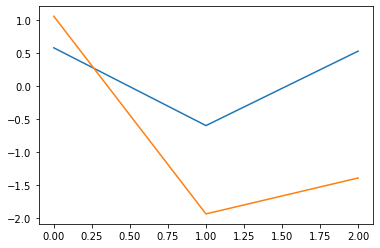

```python
# 使用matplotlib.pyplot中的plot方法绘图
plt.plot(df)
```